# Time Series Exam 1

## Data

```r
# df1 <- rio::import("https://byuistats.github.io/timeseries/data/xxxxxxxxx.csv")
```

## Questions

1. What is the term for when measurements are taken sequentially over time at a fixed interval?

   A. Seasonal variation

   B. Serial dependence

   C. Time series

   D. Sampling interval
2. What term refers to the repeating cyclical patterns seen within a fixed time period in a time series?

   A. Cycle

   B. Seasonal variation

   C. Trend

   D. Sampling interval
3. What is the process of removing systematic, non-random patterns from a time series called?

   A. Differencing

   B. Decomposition

   C. Describing

   D. Detrending
4. What function in R can be used to break down a time series into trend, seasonal, and random components?

   A. decompose()

   B. season()

   C. random()

   D. trend()
5. What type of model assumes the random component multiplies the trend and seasonal components?

   A. Multiplicative

   B. Additive

   C. Logarithmic

   D. Exponential
6. What is the term for the time difference between the current time and when a future event is predicted?

   A. Seasonality

   B. Lag

   C. Lead time

   D. Trend
7. Which plot shows the correlation between two time series at different time lags?

   A. Time plot

   B. Scatter plot

   C. Cross-correlogram

   D. Correlogram
8. Which term refers to making predictions about future values based on past patterns or trends?

   A. Extrapolating

   B. Interpolating

   C. Smoothing

   D. Decomposing
9. What does the acronym EWMA stand for?

   A. Exponentially Weighted Moving Autocorrelation

   B. Exponentially Weighted Multivariate Analysis

   C. Exponentially Weighted Moving Average

   D. None of the above
10. What is the purpose of the alpha parameter in exponential smoothing?

    A. To control the amount of smoothing

    B. To remove the seasonal component

    C. To calculate prediction errors

    D. To estimate the lag
11. The Holt-Winters method extends exponential smoothing by estimating what three components?

    A. Trend, slope, seasonal

    B. Level, seasonality, cycle

    C. Level, trend, seasonal

    D. Mean, variance, correlation
12. What does the gamma parameter control in the Holt-Winters seasonal method?

    A. The trend estimate

    B. The amount of seasonal smoothing

    C. The amount of level smoothing

    D. The lag
13. What does the predict() function do in R?

    A. Calculates predictions errors

    B. Removes prediction biases

    C. Produces future forecasts from a fitted model

    D. Implements exponential smoothing
14. Why may extrapolating patterns too far into the future lead to invalid forecasts?

    A. Time series are infinite in length

    B. The present may not resemble the future

    C. Holt-Winters will always be accurate

    D. Exponential smoothing eliminates biases
15. Time series that wander unpredictably without showing a fixed pattern or returning to a long term mean are described as:

    A. Stationary

    B. Linear

    C. Stochastic

    D. Seasonal
16. What is the term for when a time series maintains a fixed distribution as it evolves over time?

    A. Seasonality

    B. Weak stationarity

    C. Strict stationarity

    D. Long-term stationarity
17. What is a major limitation of cross-correlation analysis between two associated variables?

    A. It assumes a linear relationship

    B. It can only handle stationary time series

    C. It does not determine causality

    D. The variables must have equal variances
18. What term refers to serial correlation at a lag of 0 periods?

    A. Partial autocorrelation

    B. Zero correlation

    C. Autocorrelation

    D. Self-correlation
19. What is the purpose of finding leading indicators for a time series?

    A. To characterize trends

    B. To improve forecasts

    C. To test for stationarity

    D. To identify seasonality
20. Which plot is useful for visually identifying changes in the process mean of a time series?

    A. Autocorrelation plot

    B. Cumulative sum plot

    C. Cross-correlation plot

    D. Time series plot
21. What characteristic of a time series does the sample variance estimate?

    A. Central tendency

    B. Spread

    C. Seasonality

    D. Duration
22. What is the name of the algorithm that uses exponential smoothing to estimate level, trend, and seasonal components?

    A. ARIMA

    B. Holt-Winters

    C. Decomposition

    D. Exponential regression
23. What term refers to a fitted time series model providing a concise summary of the main characteristics of the data?

    A. Principal component

    B. Parsimony

    C. Decomposition

    D. Extrapolation
24. Which plot displays a time series clearly emphasizing patterns and potential outliers?

    A. Histogram

    B. Time plot

    C. Scatter plot

    D. Spectrum
25. What does taking the logarithm of a time series prior to analysis achieve?

    A. Removes heteroscedasticity

    B. Induces stationarity

    C. Transforms a multiplicative model to an additive one

    D. Reduces bias in the mean
26. What is the main purpose of diagnostic checking of fitted time series models?

    A. Improving accuracy of forecasts

    B. Assessing suitability of the fitted model

    C. Determining optimal smoothing parameters

    D. Testing for stationarity
27. What concept suggests exponential smoothing may perform poorly if based solely on past data?

    ```
    A. Recency effect
    ```

    B. Outlier sensitivity

    C. Mean reversion

    D. Forward estimation
28. What potential pitfall arises from the use of multiple hypothesis testing in correlogram interpretation?

    A. Confidence may exceed certainty

    B. Low power

    C. Negative autocorrelation

    D. Heteroscedasticity
29. Consider this figure, which was created for a time series where the measurements are made one month apart.

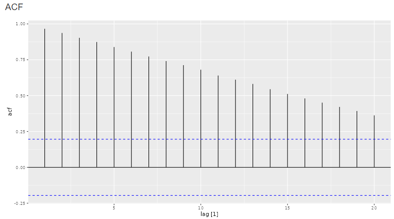

If the time series reaches a record high in September, what can we infer about the value of the time series in October?

1. It must be a new record high.
2. The value should be high, but not necessarily a record.
3. The value will be very low, possibly even a new record low.
4. We have not idea what to expect in October.

Given the figure

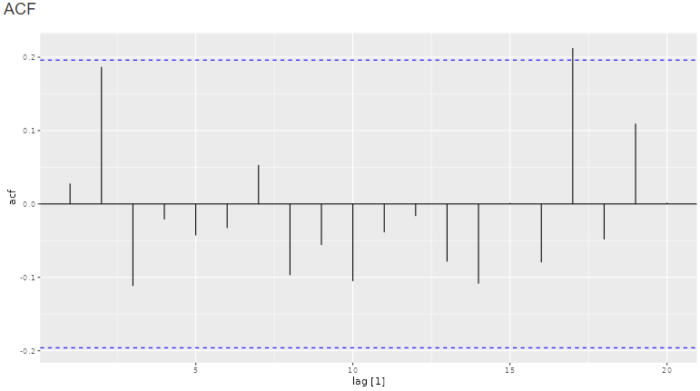

answer the following questions:

#### A) Give the name of this plot.

#### B) Explain what this plot shows. Be sure to describe the characteristics of the time series that would have generated this plot.

#### C) Sketch a time series that might lead to a plot like this.

### Question 3 - The figure below is an additive decomposition for a time series. Is the additive model appropriate for these data. Why or why not?

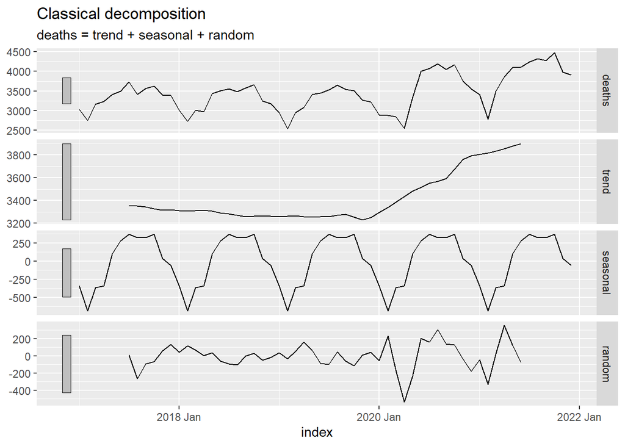

Read in the following data file

```r
temp1 <- rio::import("../data/test1_winter24_data1.csv")
```

What is the value of the times series in July 2021?